# Importacion de las bibliotecas a utilizar

```python
import numpy as np
import pandas as pd
import matplotlib as plt
from sklearn.impute import SimpleImputer
import matplotlib.pyplot as plt
import seaborn as sns
import missingno as msno
import os
```

# Importacion de los datos

```python
#Importar la base de datos
df = pd.read_csv('titanic3.csv')
orig_df=df
#print(df)
```

# Capitulo 4 : Examinando los datos perdidos

```python
df.isnull().mean() * 100
```

```
pclass        0.000000
survived      0.000000
name          0.000000
sex           0.000000
age          20.091673
sibsp         0.000000
parch         0.000000
ticket        0.000000
fare          0.076394
cabin        77.463713
embarked      0.152788
boat         62.872422
body         90.756303
home.dest    43.086325
dtype: float64
```

*El código que se proporciono utiliza la biblioteca **`missingno`** missingno para visualizar la matriz de **nulos** en un conjunto de datos.Inicialmente usaremos el comando **`msno.matrix()`**, que muestra una matriz de atributos en la que las líneas blancas significan la existencia de datos faltantes, y cuantas más líneas, más datos faltan.*

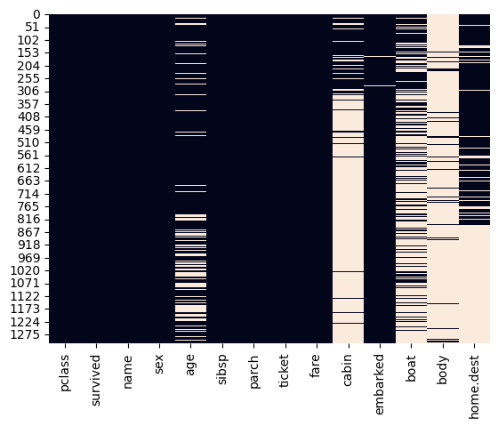

```python
# Identificamos los missing values visualmente
sns.heatmap(df.isnull(), cbar=False)
```

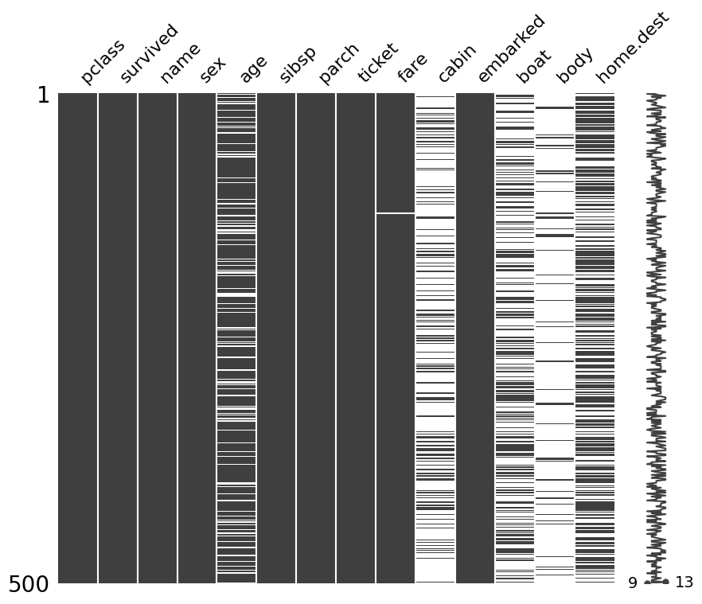

```python
image_dir = "images"
# Crea el directorio si no existe
os.makedirs(image_dir, exist_ok=True)
ax = msno.matrix(orig_df.sample(500), figsize=(10,8))
ax.get_figure().savefig("images/mlpr_0401.png")
```

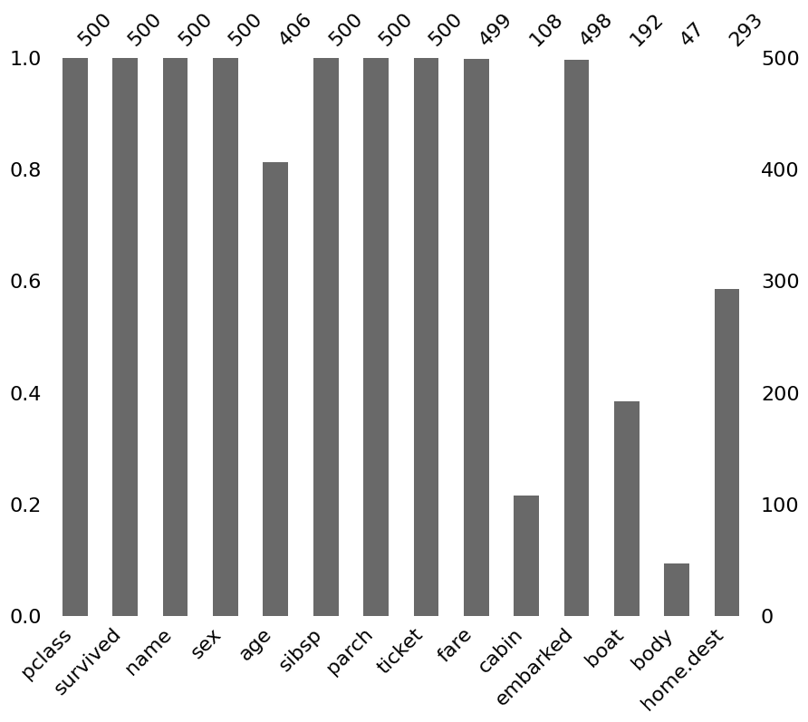

```python
ax = msno.bar(orig_df.sample(500), figsize=(10,8))
ax.get_figure().savefig("images/mlpr_0403.png")
```

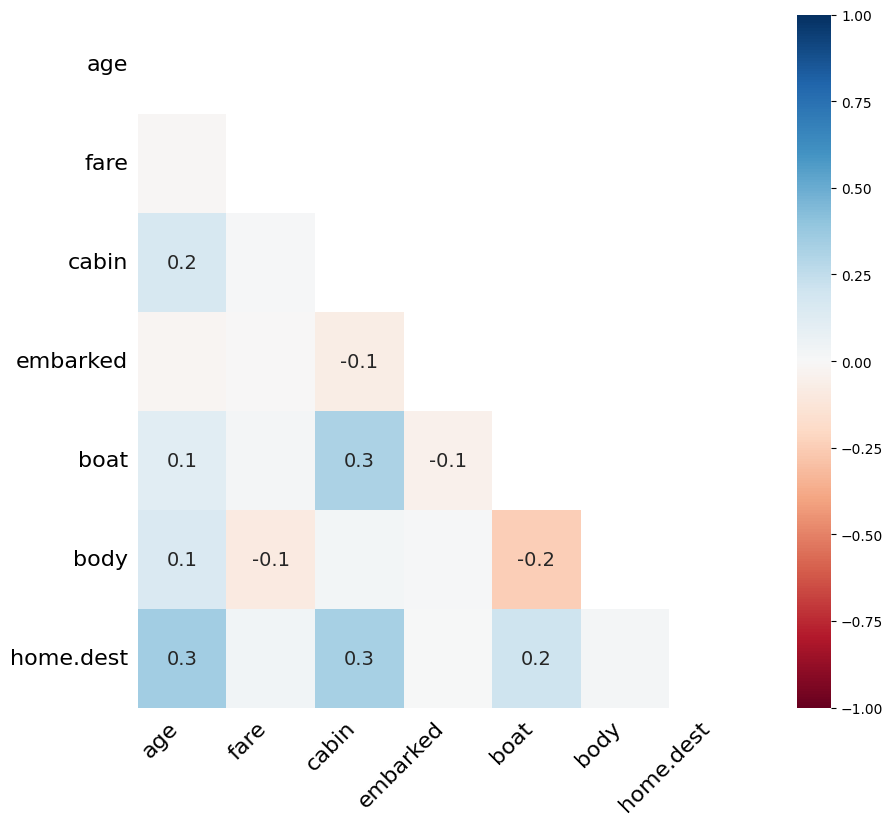

```python
ax = msno.heatmap(df, figsize=(10, 9))
ax.get_figure().savefig("images/mlpr_0404.png")
```

*Finalmente, se introducirá el comando **`msno.dendrogram()`**, que traza un dendrograma (un diagrama de árbol) que mostrará de forma más completa la correlación entre las variables, revelando conexiones más complejas que las visibles en el mapa de calor.*

*Para construir el dendrograma, el modelo utiliza un algoritmo de agrupamiento jerárquico para agrupar las variables por su correlación nula (si desea comprender mejor cómo se realiza el algoritmo, simplemente eche un vistazo a este enlace). Su interpretación debe hacerse de arriba a abajo.*

*En la parte inicial igual a 0, que una variable esté vinculada a otra significa que siempre se puede llenar una de ellas cuando la otra está vacía, o ambas siempre se pueden llenar/vaciar.*

*En divisiones cercanas a 0, los atributos se predicen bien entre sí, pero no perfectamente como lo hicieron en la fila 0 y así sucesivamente.*

*link_documentacion="https://docs.scipy.org/doc/scipy/reference/generated/scipy.cluster.hierarchy.linkage.html#scipy.cluster.hierarchy.linkage"*

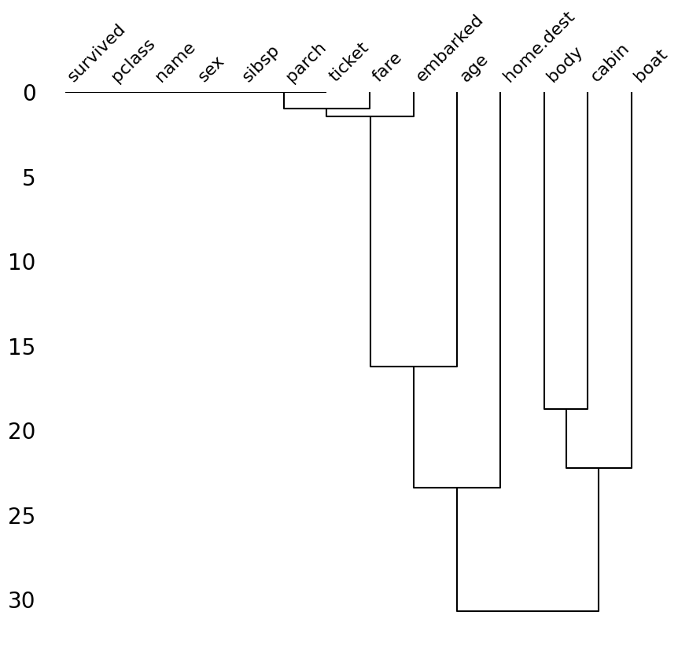

```python
ax = msno.dendrogram(df, figsize=(10, 9))
ax.get_figure().savefig("images/mlpr_0405.png")
```

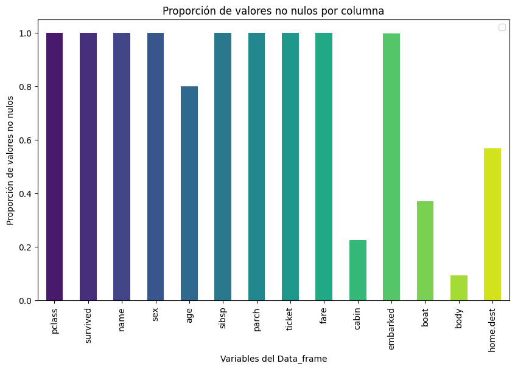

```python
# Crear una figura (fig) y ejes (ax) utilizando subplots
fig, ax = plt.subplots(figsize=(10, 6))

# Calcular la proporción de valores no nulos en cada columna y restarla de 1
# Luego, trazar un gráfico de barras de estas proporciones en el eje ax
bar_plot = (1 - df.isnull().mean()).abs().plot.bar(ax=ax, color=sns.color_palette("viridis", len(df.columns)))

# Personalizar la apariencia del gráfico
ax.set_title('Proporción de valores no nulos por columna')
ax.set_ylabel('Proporción de valores no nulos')
ax.set_xlabel('Variables del Data_frame')
ax.legend([])  # Oculta la leyenda para las barras de colores

# Guardar la figura en un archivo de imagen llamado "mlpr_0402.png" con una resolución de 300 ppp
fig.savefig("images/mlpr_0402.png", dpi=300)

# Mostrar el gráfico
plt.show()
```

# Eliminacion de datos perdidos

*El código **`df1 = df.dropna()`** elimina todas las **filas** del DataFrame df que contienen al menos un valor nulo. La función dropna() devuelve un nuevo DataFrame donde se han eliminado todas las filas que contenían valores nulos en alguna de sus columnas. En otras palabras, df1 contendrá solo las filas que no tienen ningún valor nulo en ninguna de sus columnas.*

```python
df1 = df.dropna()
print(df1)
```

```
Empty DataFrame
Columns: [pclass, survived, name, sex, age, sibsp, parch, ticket, fare, cabin, embarked, boat, body, home.dest]
Index: []
```

*El código **`df1 = df.drop(columns="cabin")`** elimina la columna llamada "cabin" del DataFrame df y asigna el resultado a un nuevo DataFrame llamado df1. La función drop(columns="cabin") elimina la columna especificada ("cabin" en este caso) del DataFrame y devuelve un nuevo DataFrame sin esa columna.*

```python
df1 = df.drop(columns="cabin")
#print(df1)
```

# Llenado de datos vacios

*Manejo de valores faltantes="https://deepnote.com/@mazzaroli/Manejo-de-Datos-Faltantes-Imputacion-3b4b1f7b-d5c5-45ae-894c-29223471edd4"*

```python
# Selecciona las columnas numéricas del DataFrame df y obtiene sus nombres de columna. Estas columnas se utilizarán para la imputación
num_cols = df.select_dtypes(include="number").columns
# Crea una instancia de SimpleImputer sin especificar ningún parámetro adicional, lo que significa que se utilizará la estrategia de imputación por defecto, que es la media (mean).
im = SimpleImputer()
# Aplica la imputación a las columnas numéricas seleccionadas. La función fit_transform ajusta el imputador a los datos y transforma (imputa) los valores faltantes.
imputed = im.fit_transform(df[num_cols])
```

```python
# Convertir el arreglo NumPy a un DataFrame de pandas
imputed_df = pd.DataFrame(imputed, columns=num_cols)
# Calcular el porcentaje de valores nulos en el DataFrame
percentage_missing = imputed_df.isnull().mean() * 100
print(percentage_missing)
```

```
pclass      0.0
survived    0.0
age         0.0
sibsp       0.0
parch       0.0
fare        0.0
body        0.0
dtype: float64
```

Una vez que tenga una herramienta para predecir datos, podrá usarla para predecir datos faltantes. La tarea general de definir valores para Los valores faltantes se llaman imputación. Si está imputando datos, necesitará crear una canalización y utilizar la misma lógica de imputación durante la creación del modelo y tiempo de predicción. La clase SimpleImputer en scikit-learn Manejar valores de características medias, medianas y más frecuentes. El comportamiento predeterminado es calcular la media:

*Proporcione estrategia='mediana' o estrategia='más_frecuente' a cambie el valor reemplazado a mediana o más común, respectivamente. Si desea completar con un valor constante, digamos -1, use estrategia='constante' en combinación con fill_value=-1.*

**CONSEJO** *Puedes usar el método **`fillna`** en pandas para imputar valores faltantes también. Asegúrate de no filtrar datos aunque. Si está completando con el valor medio, asegúrese de utiliza el mismo valor medio durante la creación del modelo y tiempo de predicción del modelo.*

# Añadir indicadores a las columnas

*La falta de datos en sí misma puede proporcionar alguna señal a un modelo. La biblioteca pandas puede agregar una nueva columna para indicar que faltaba un valor:*

```python
def add_indicator(col):
    def wrapper(df):
        return df[col].isna().astype(int)
    return wrapper
df1 = df.assign(cabin_missing=add_indicator("cabin"))
print(df1)
```

```
      pclass  survived                                             name  \
0          1         1                    Allen, Miss. Elisabeth Walton
1          1         1                   Allison, Master. Hudson Trevor
2          1         0                     Allison, Miss. Helen Loraine
3          1         0             Allison, Mr. Hudson Joshua Creighton
4          1         0  Allison, Mrs. Hudson J C (Bessie Waldo Daniels)
...      ...       ...                                              ...
1304       3         0                             Zabour, Miss. Hileni
1305       3         0                            Zabour, Miss. Thamine
1306       3         0                        Zakarian, Mr. Mapriededer
1307       3         0                              Zakarian, Mr. Ortin
1308       3         0                               Zimmerman, Mr. Leo

         sex    age  sibsp  parch  ticket      fare    cabin embarked boat  \
0     female  29.00      0      0   24160  211.3375       B5        S    2
```

[output cut: 25 more lines]